# Сетевые технологии

Лабораторная работа №8

Элсаиед Адел

Российский университет дружбы народов, Москва, Россия

11 марта 2026

# Цели и задачи работы

## Цель лабораторной работы

Изучение принципов маршрутизации в IPv4- и IPv6-сетях и принципов настройки сетевого оборудования.

## Задачи работы

- смоделировать сеть в **GNS3**
- настроить адресацию **IPv6** на VPCS и маршрутизаторах **VyOS**
- проверить работу механизма **Router Advertisement**
- настроить динамическую маршрутизацию **IPv4** с использованием **RIP**
- создать туннель **IPv6 over IPv4**
- проанализировать сетевой трафик в **Wireshark**

# Ход выполнения работы

## Топология сети в GNS3

- Использованы три маршрутизатора **VyOS**
- Добавлены два Ethernet-коммутатора и два узла **VPCS**
- Между `msk-elsaiedadel-gw-01` и `msk-elsaiedadel-gw-03` подключён анализатор трафика

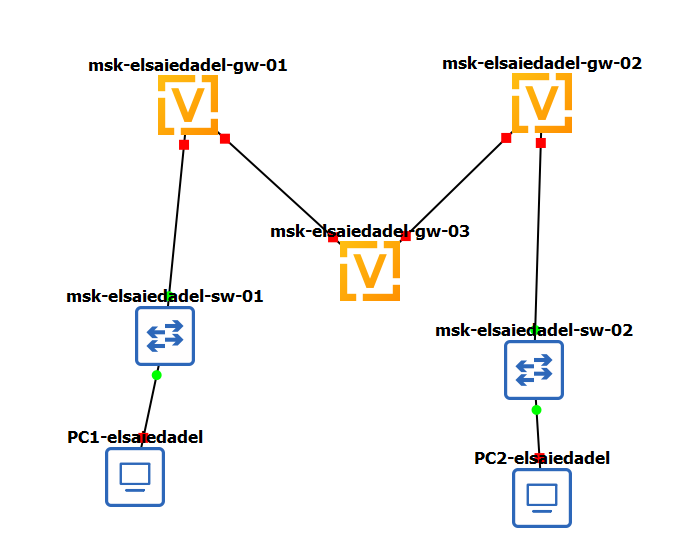

Топология сети в GNS3

## Настройка IPv6 на PC1

- Узлу `PC1-elsaiedadel` назначен адрес `1000::a/64`
- Конфигурация сохранена командой `save`
- Выполнена проверка параметров `show ipv6`

[figure not shown]

Настройка IPv6 на PC1

## Настройка IPv6 на PC2

- Узлу `PC2-elsaiedadel` назначен адрес `1002::a/64`
- Конфигурация сохранена
- Выполнен вывод текущих IPv6-параметров

[figure not shown]

Настройка IPv6 на PC2

## Настройка маршрутизатора gw-01

- На `eth0` задан IPv6-адрес `1000::1/64`
- На `eth1` задан IPv4-адрес `10.0.0.1/8`
- Настроен **Router Advertisement** для префикса `1000::/64`

[figure not shown]

Настройка интерфейсов маршрутизатора gw-01

## Настройка маршрутизатора gw-02

- На `eth0` задан IPv6-адрес `1002::1/64`
- На `eth1` задан IPv4-адрес `20.0.0.2/8`
- Включён **Router Advertisement** для префикса `1002::/64`

[figure not shown]

Настройка интерфейсов маршрутизатора gw-02

## Настройка маршрутизатора gw-03

- На `eth0` назначен адрес `10.0.0.2/8`
- На `eth1` назначен адрес `20.0.0.1/8`
- Конфигурация применена и сохранена

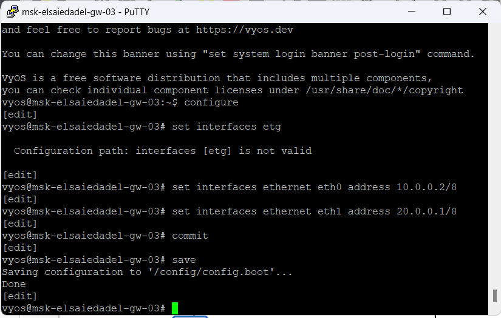

Настройка интерфейсов маршрутизатора gw-03

## Проверка Router Advertisement на PC1

- Выполнена команда `show ipv6`
- Подтверждено получение адреса ближайшего маршрутизатора
- Зафиксирована корректная локальная IPv6-конфигурация

[figure not shown]

Проверка IPv6 параметров PC1

## Проверка Router Advertisement на PC2

[figure not shown]

Проверка IPv6 параметров PC2

## Проверка маршрутов до настройки RIP

- С `msk-elsaiedadel-gw-01` выполнены проверки:
  - `ping 10.0.0.2` — успешно
  - `ping 20.0.0.1` — сеть недоступна
  - `ping 20.0.0.2` — сеть недоступна
- Отсутствовал маршрут в сеть `20.0.0.0/8`

[figure not shown]

Проверка связности до настройки RIP

## Анализ трафика до настройки RIP

- В Wireshark наблюдаются **ARP** и **ICMP**
- Для сети `10.0.0.0/8` выполняется ARP-разрешение
- Трафик к сети `20.0.0.0/8` отсутствует из-за отсутствия маршрута

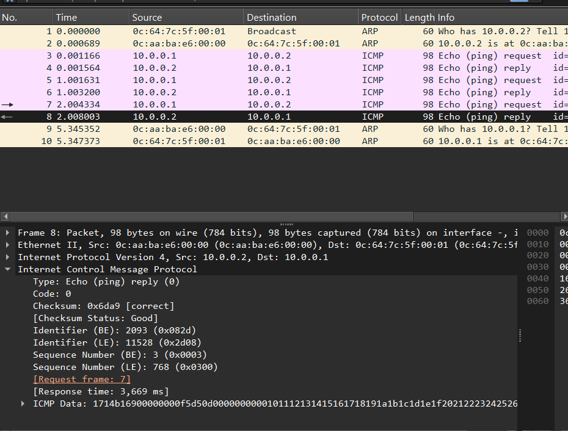

Анализ трафика до настройки RIP

## Настройка RIP на gw-01

- Включён протокол **RIP**
- В конфигурацию добавлена сеть `10.0.0.0/8`
- Изменения подтверждены командами `commit` и `save`

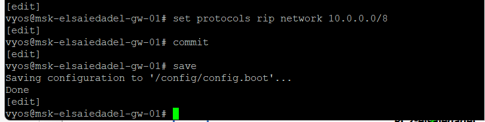

Настройка RIP на маршрутизаторе gw-01

## Настройка RIP на gw-02 и gw-03

- На `gw-02` добавлена сеть `20.0.0.0/8`
- На `gw-03` добавлены сети:
  - `10.0.0.0/8`
  - `20.0.0.0/8`
- Центральный маршрутизатор начал обмен маршрутами между сегментами

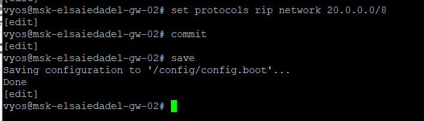

Настройка RIP на маршрутизаторе gw-02

## Настройка RIP на gw-02 и gw-03

[figure not shown]

Настройка RIP на маршрутизаторе gw-03

## Проверка маршрутов после настройки RIP

- Все проверки с `gw-01` завершились успешно:
  - `ping 10.0.0.2`
  - `ping 20.0.0.1`
  - `ping 20.0.0.2`
- Связность между IPv4-сетями обеспечена

[figure not shown]

Проверка связности после настройки RIP

## Анализ трафика после настройки RIP

- В захвате появились пакеты **RIPv2**
- Обмен маршрутами выполняется через мультикаст-адрес `224.0.0.9`
- Одновременно фиксируется успешный обмен **ICMP** между удалёнными сетями

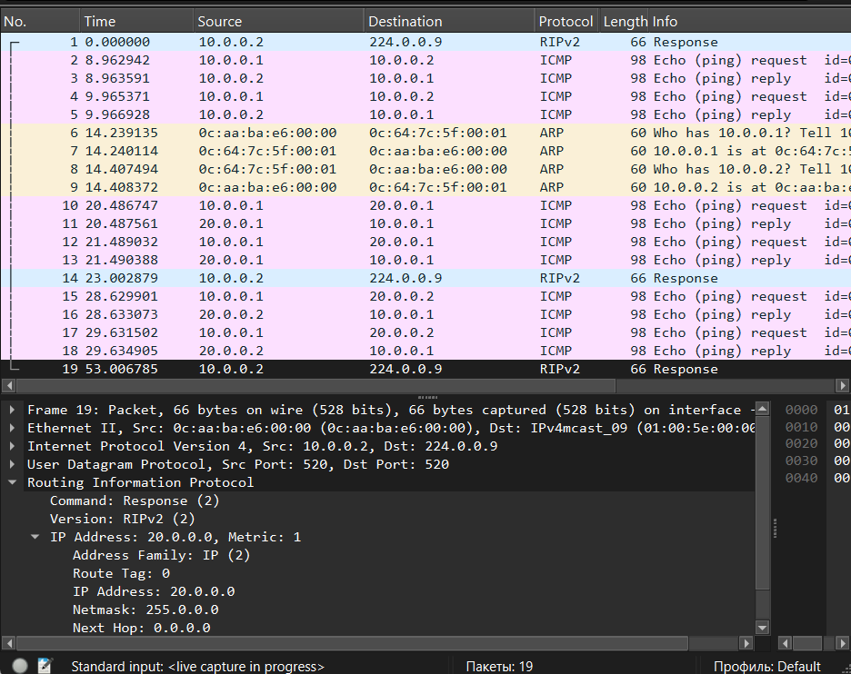

Анализ трафика после настройки RIP

## Создание IPv6-over-IPv4 туннеля

- На `gw-01` создан интерфейс `tun0`
- Тип инкапсуляции: `sit`
- Концы туннеля:
  - `10.0.0.1`
  - `20.0.0.2`
- Назначен адрес `1001::1/64`
- Добавлен статический маршрут к сети `1002::0/64`

## Создание IPv6-over-IPv4 туннеля

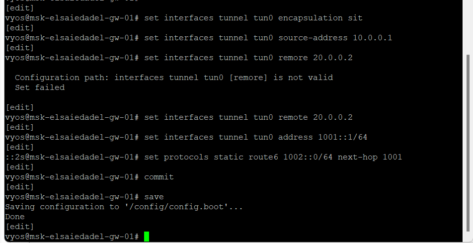

Настройка IPv6-over-IPv4 туннеля на маршрутизаторе gw-01

## Завершение настройки туннеля на gw-02

- На `gw-02` создан интерфейс `tun0`
- Назначен адрес `1001::2/64`
- Добавлен статический маршрут к сети `1000::0/64`
- Обеспечена двусторонняя IPv6-связность через IPv4-сеть

[figure not shown]

Настройка IPv6-over-IPv4 туннеля на маршрутизаторе gw-02

## Проверка доступности оконечных устройств

- С `PC1` выполнены:
  - `ping 1002::a`
  - `trace 1002::a`
- С `PC2` выполнены:
  - `ping 1000::a`
  - `trace 1000::a`
- Трассировка подтвердила прохождение через туннельные адреса `1001::1` и `1001::2`

## Проверка доступности оконечных устройств

[figure not shown]

Проверка доступности PC2 с PC1

## Проверка доступности оконечных устройств

[figure not shown]

Проверка доступности PC1 с PC2

## Анализ туннельного трафика

- IPv6-пакеты передаются через IPv4-сеть в инкапсулированном виде
- Во внешнем заголовке используются IPv4-адреса `10.0.0.1` и `20.0.0.2`
- Поле `Protocol = 41` указывает на перенос IPv6 внутри IPv4
- Во внутреннем заголовке сохраняются реальные IPv6-адреса узлов `1000::a` и `1002::a`

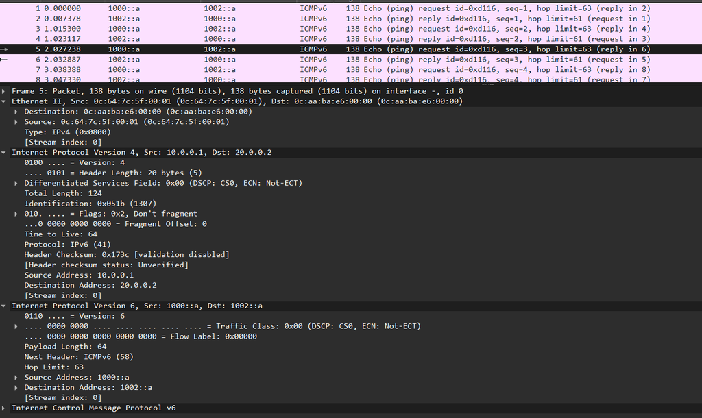

Инкапсуляция IPv6-пакета в IPv4 в Wireshark

# Итоги

## Заключение

В ходе выполнения лабораторной работы была смоделирована сеть в среде **GNS3** с использованием маршрутизаторов **VyOS**, коммутаторов и виртуальных оконечных устройств **VPCS**. В процессе работы выполнена настройка **IPv6-адресации** оконечных устройств и интерфейсов маршрутизаторов, а также обеспечено автоматическое распространение IPv6-префиксов с помощью механизма **Router Advertisement**.

Далее была реализована динамическая маршрутизация **IPv4** с использованием протокола **RIP**, что позволило обеспечить обмен маршрутной информацией между маршрутизаторами и организовать связность между удалёнными сегментами сети. Проверка маршрутов и анализ трафика показали корректное распространение маршрутных записей и передачу пакетов между сетями.

На заключительном этапе был создан туннель **IPv6 через IPv4** с использованием механизма инкапсуляции **SIT**. Выполнена настройка статической маршрутизации **IPv6** между сегментами сети, после чего подтверждена доступность оконечных устройств с помощью команд `ping` и `trace`. Анализ трафика в **Wireshark** показал процесс инкапсуляции IPv6-пакетов во внешний IPv4-заголовок и позволил определить прохождение пакетов через туннель.